# 迴歸分析(Regression)

Yao-Jen Kuo

June, 2016

# 摘要

- 單變數
- 多變數
- GLM & GAM

# 從氣溫與冰紅茶銷量開始

- 平均氣溫與手搖飲料店冰紅茶銷量的關係為何?
- 通常會先畫一個 `scatterplot` 散佈圖來看關係

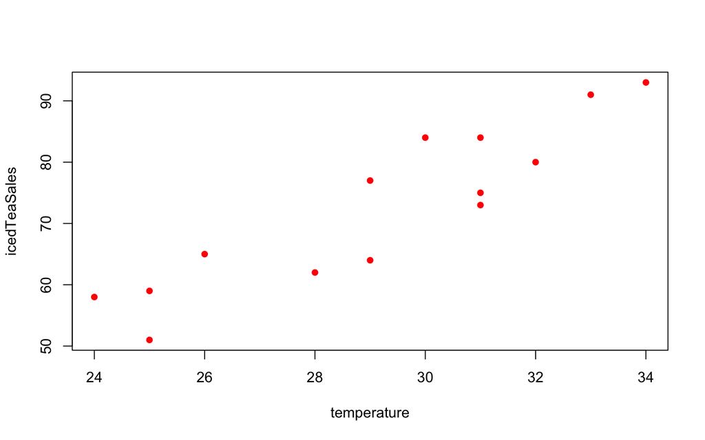

```r
temperature <- c(29, 28, 34, 31, 25, 29, 32, 31, 24, 33, 25, 31, 26, 30)
icedTeaSales <- c(77, 62, 93, 84, 59, 64, 80, 75, 58, 91, 51, 73, 65, 84)
plot(x = temperature, y = icedTeaSales, col = "red", pch = 16)
```

- 這個關係看起來可以用一條直線來描述
- 我們會從很多條線中選一條最**fit**的線出來

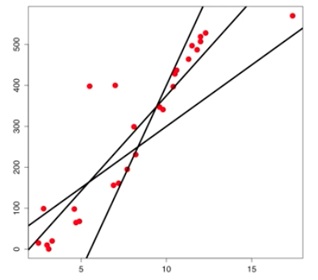

Source: Google Search

# 什麼是最fit的線?

- 最**fit**的線長這個樣子

$$Y = \beta_o + \beta_1X + \epsilon$$

- 計算每一點跟這條線的差距: $res_i$

$$res_i = y_i - (\beta_0 + \beta_1x_i)$$

- 最小化$res_i$的平方和

$$Min. SS_{res} = \sum_{i = 1}^N(res_i) ^ 2$$

# 什麼是最fit的線 - Hands on

- 使用 `lm()` 函數來為你做好這些事情
- 在 R Console 輸入 `?lm` 來看看這個函數

```r
icedTeaData <- data.frame(temperature = temperature, icedTeaSales = icedTeaSales)
lmIcedTea <- lm(formula = icedTeaSales ~ temperature, data = icedTeaData)
lmIcedTea$coefficients
```

```
## (Intercept) temperature
##  -36.361233    3.737885
```

```r
toBePredicted <- data.frame(temperature = 30)
predicted <- predict(lmIcedTea, newdata = toBePredicted)
predicted
```

```
##        1
## 75.77533
```

# 什麼是最fit的線 - Do It Yourself

- 使用內建資料集 `cars`
- 畫出散佈圖, X軸為速度, Y軸為煞車距離
- 預測速度26, 煞車距離為何

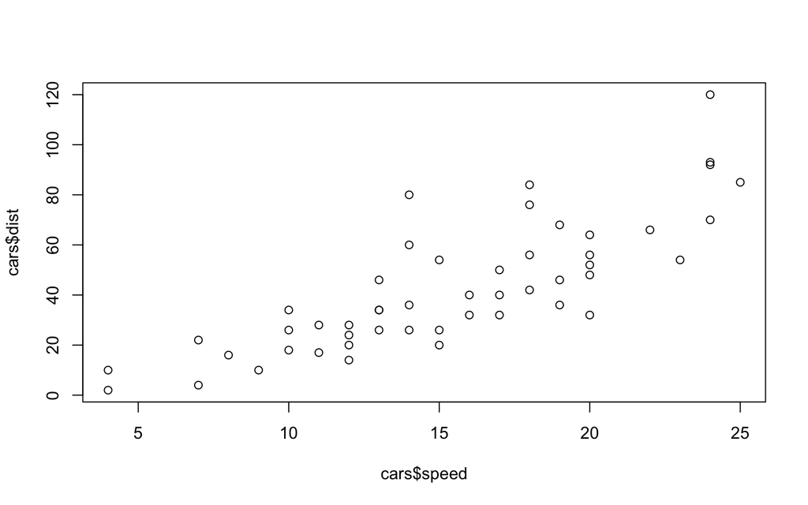

```r
plot(x = cars$speed, y = cars$dist)
```

```r
lmCars <- lm(formula = dist ~ speed, data = cars)
toBePredicted <- data.frame(speed = 26)
predicted <- predict(lmCars, newdata = toBePredicted)
predicted
```

```
##        1
## 84.66353
```

# 如何判斷迴歸模型的表現?

- RMSE(愈低愈好)

$$RMSE = \sqrt{\frac{1}{N}\sum_{i=1}^N(y_i - \hat{y}_i) ^ 2}$$

- R-squared(愈接近1愈好)

$$SS_res = \sum_{i=1}^N(y_i - \hat{y}_i) ^ 2$$
$$SS_tot = \sum_{i=1}^N(y_i - \bar{y}) ^ 2$$
$$R^2 = 1 - \frac{SS_{res}}{SS_{tot}}$$

# 如何判斷迴歸模型的表現 - Hands on

```r
icedTeaSalesEst <- predict(lmIcedTea, newdata = data.frame(icedTeaData[, 1]))

# 計算RMSE
res <- icedTeaData$icedTeaSales - icedTeaSalesEst
rmse <- sqrt( sum(res^2) /nrow(icedTeaData) )
rmse
```

```
## [1] 5.285344
```

```r
# 計算R-squared
ss_res <- sum (res ^ 2)
ss_tot <- sum( (icedTeaData$icedTeaSales - mean(icedTeaData$icedTeaSales))^2 )
r_sq <- 1 - ss_res / ss_tot
r_sq
```

```
## [1] 0.8225093
```

```r
# 跟 summary() 的結果比較
summary(lmIcedTea)$r.squared
```

```
## [1] 0.8225093
```

# 如何判斷迴歸模型的表現 - Do It Yourself

- 使用內建資料集 `cars`
- 計算rmse
- 計算R-squared
- 跟 `summary()` 的結果比較

```r
carsSpeed <- data.frame(cars$speed)
names(carsSpeed) <- "speed"
carsEst <- predict(lmCars, newdata = carsSpeed)

# 計算RMSE
res <- cars$dist - carsEst
rmse <- sqrt( sum(res^2) /nrow(cars) )
rmse
```

```
## [1] 15.06886
```

```r
# 計算R-squared
ss_res <- sum (res ^ 2)
ss_tot <- sum( (cars$dist - mean(cars$dist))^2 )
r_sq <- 1 - ss_res / ss_tot
r_sq
```

```
## [1] 0.6510794
```

```r
# 跟 summary() 的結果比較
summary(lmCars)$r.squared
```

```
## [1] 0.6510794
```

# 加入更多的變數

- 除了氣溫會影響冰紅茶的銷售量, 你覺得還有其他因素會影響冰紅茶銷量
- 像是奶茶的銷量, 當天鄰近友商是否有促銷活動…等
- 加入更多變數可以提高模型預測的精準度
- 最**fit**的面變為

$$Y = \beta_o + \beta_1X_1 + \beta_2X_2 + \epsilon$$

- 計算每一點跟這條面的差距: $res_i$

$$res_i = y_i - (\beta_0 + \beta_1x_{i1} + \beta_2x_{i2})$$

- 最小化$res_i$的平方和

$$Min. SS_{res} = \sum_{i = 1}^N(res_i) ^ 2$$

# 加入更多的變數 - Hands on

- 很可惜我們沒有奶茶的銷量…
- 我們改用 `chocolate.csv` 資料集練習

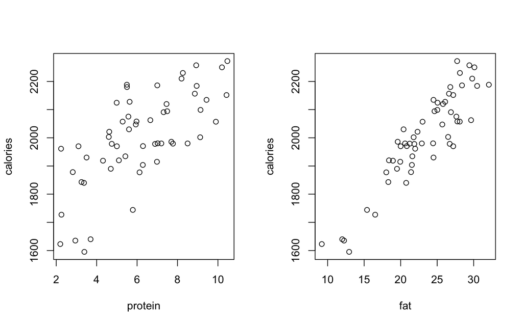

```r
chocolate <- read.csv("/Users/tkuo/ntu_train/NTUTrainRL3/data/chocolate.csv")
par(mfrow=c(1, 2))
plot(calories ~ protein, chocolate)
plot(calories ~ fat, chocolate)
```

```r
# 單變數
chocoSingleVar <- lm(formula = calories ~ protein, data = chocolate)
summary(chocoSingleVar)$r.squared
```

```
## [1] 0.4944082
```

```r
# 雙變數
chocoTwoVars <- lm(formula = calories ~ protein + fat, data = chocolate)
summary(chocoTwoVars)$adj.r.squared
```

```
## [1] 0.8945784
```

- 多納入脂肪含量使模型的R平方增加到接近0.9

# 加入更多的變數 - Do It Yourself

- 將熱量對大小 `size` 作圖
- 將 `size` 也納入

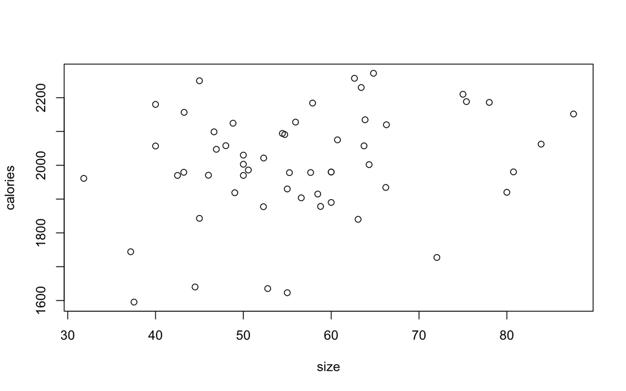

```r
plot(calories ~ size, chocolate)
```

```r
chocoThreeVars <- lm(formula = calories ~ protein + fat + size, data = chocolate)
summary(chocoThreeVars)$adj.r.squared
```

```
## [1] 0.8962204
```